# BANTER for Beaked Whales: Hawaii

Shannon Rankin

2023-02-06

## PAMpal Data Processing

Start by loading the required packages

```r
library(PAMpal)
library(banter)
library(rfPermute)
library(kableExtra)
library(here)
here()
```

```
## [1] "C:/Users/shannon.rankin/Documents/GitHub/BANTER_BeakedWhales"
```

1. Set up our PPS (PAMPal Settings Object) for the Hawaii dataset

```r
pps <- PAMpalSettings(db='Database/',
                      binaries = 'Binaries/',
                      sr_hz='auto',
                      winLen_sec=.0025,
                      filterfrom_khz=10,
                      filterto_khz=NULL)
```

2. Process data and save to file to eliminate repeated processing.

If you have already run the processing code, ensure you have set ‘freshRun = FALSE’ at top of this document to read in the existing .rds file for downstream processing.

If this is the initial processing, ensure you have set ‘freshRun = TRUE’ at top of this document to process and save data. This will take some time to run.

```r
data <- processPgDetections(pps, mode='db', id='hawaii_bw')
saveRDS(data, 'hawaii_study.rds')
# Double check warning messages
print(getWarnings(data)$message)
```

3. Assign species identity according to original PAMguard labels, then relabel for consistency across projects.

```r
data <- setSpecies(data, 'pamguard')
reSpecies <- readRDS('species.rds')
print(reSpecies)
```

```
##     X     old      new
## 1  11     ?BW   possBW
## 2  38     ?GG   possGG
## 3  13   ?NBHF possNBHF
## 4  17     ?PM   possPM
## 5  22     ?Pm   possPM
## 6   9     BW?   possBW
## 7   7 BW26.47       BW
## 8   8 BW26-47       BW
## 9   1 BW34.50    BW39V
## 10  2 BW34-50    BW39V
## 11  6    BW38       BW
## 12  3    BW46       MS
## 13  4 BW50.75       MS
## 14  5 BW50-75       MS
## 15 18  BWunid       BW
## 16 42      Oo       OO
## 17 36      Pm       PM
## 18 44    Ship     SHIP
## 19 10      Zc       ZC
```

```r
data <- setSpecies(data, 'reassign', value=reSpecies)
```

```
## 5 species (MD, IP, BWC, ZC, BW) were not in reassignment dataframe, they have not been changed.
```

3. Filter out unwanted data: (1) subset and rename species for BANTER model and (2) filter to retain only Channel 1.

```r
goodSpecies<- c("ZC", "MD", "BW", "BWC", "IP", "BW", "possBW")
data <- filter(data, species %in% goodSpecies)
data <- setSpecies(data, method='reassign',
                   value=data.frame(old=c('ZC', 'MD', 'BWC', 'IP'), new=c("Cuviers", "Blainsvilles", "CrossSeamount", "Longmans")))
```

```
## 2 species (possBW, BW) were not in reassignment dataframe, they have not been changed.
```

```r
data_ch1only <- filter(data, Channel == '1')
```

5. Calculate Inter-Click Interval (ICI).

```r
data_ch1only <- calculateICI(data_ch1only, time='peakTime')
```

6. Export data for BANTER (and drop species codes that will not be used for training). We will create two datasets: one with ICI and one without ICI, and save these for import into BANTER.

```r
banter_data <- export_banter(data_ch1only, dropSpecies = c('BW', 'possBW'),
                         dropVars = c('All_ici'), training=TRUE)
saveRDS(banter_data, file='hawaii_banter_data.rds')

banter_data_ici <- export_banter(data_ch1only, dropSpecies = c("BW", "possBW"), training=TRUE)
saveRDS(banter_data_ici, file='hawaii_banter_data_ici.rds')

#save update of Acoustic Study
saveRDS(data_ch1only, 'hawaii_study.rds')
```

## Build a BANTER Classification Model

### *Model without ICI*

Load data, initialize a BANTER model, and create an initial BANTER detector model (stage 1).

```r
banter_model <- initBanterModel(banter_data$events)
banter_model <- addBanterDetector(banter_model, banter_data$detectors, ntree=5e3, sampsize=10, importance = TRUE)
```

Check for stability (are more trees needed?) before moving on

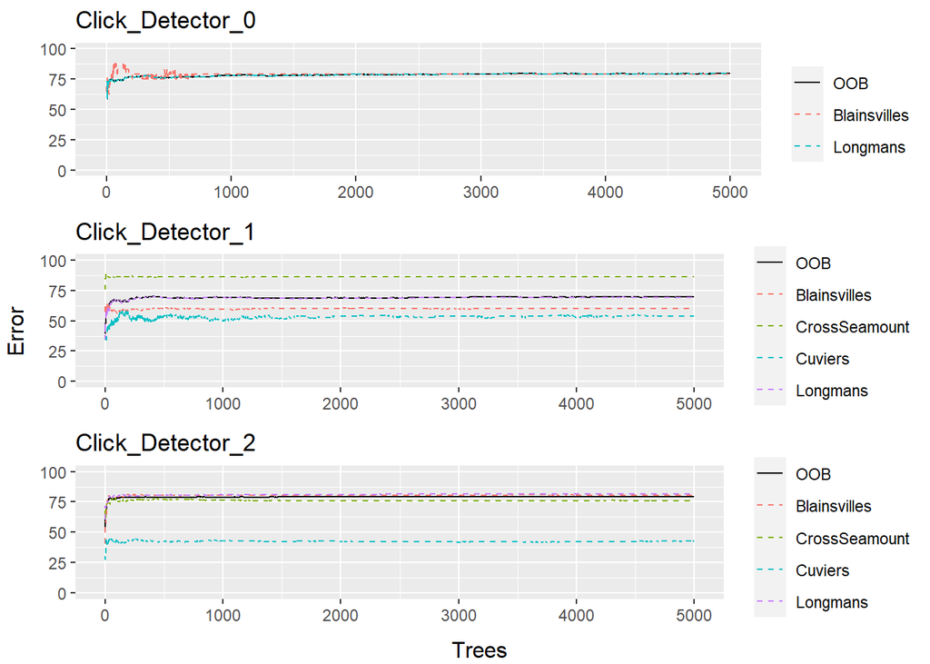

```r
plotDetectorTrace(banter_model, detector = paste0('Click_Detector_', 0:2))
```

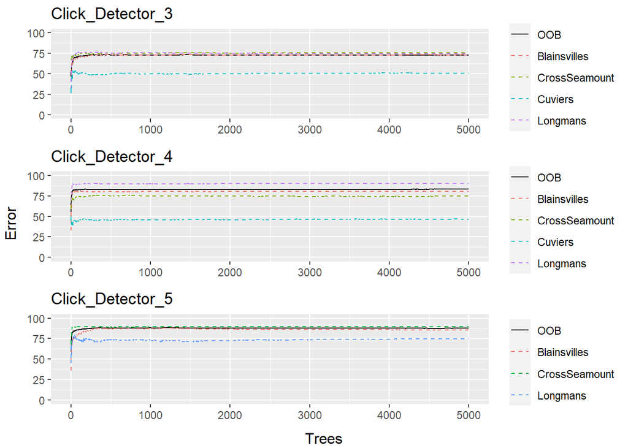

```r
plotDetectorTrace(banter_model, detector = paste0('Click_Detector_', 3:5))
```

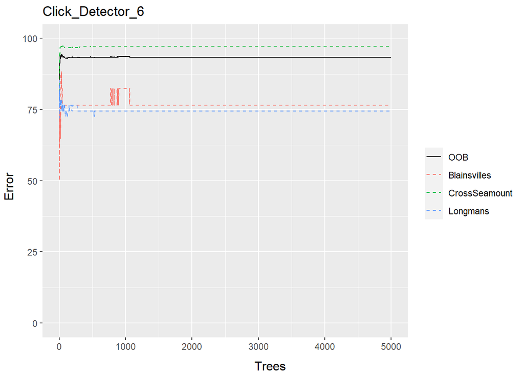

```r
plotDetectorTrace(banter_model, detector = paste0('Click_Detector_', 6))
```

```r
summary(banter_model)
```

```
## Model run times:
##                  start                 stop                  run.time
## Click_Detector_0 "2023-02-10 07:05:13" "2023-02-10 07:05:15" "1.56 secs"
## Click_Detector_1 "2023-02-10 07:03:12" "2023-02-10 07:05:13" "2.01 mins"
## Click_Detector_2 "2023-02-10 06:47:30" "2023-02-10 06:53:53" "6.38 mins"
## Click_Detector_3 "2023-02-10 06:53:53" "2023-02-10 07:01:21" "7.47 mins"
## Click_Detector_4 "2023-02-10 07:01:21" "2023-02-10 07:03:12" "1.85 mins"
## Click_Detector_5 "2023-02-10 07:05:15" "2023-02-10 07:05:21" "5.65 secs"
## Click_Detector_6 "2023-02-10 07:05:13" "2023-02-10 07:05:13" "0.56 secs"
## event            "2023-02-10 07:21:41" "2023-02-10 07:21:59" "18.03 secs"
##
## Number of events and model classification rate:
##         species num.events Click_Detector_0 Click_Detector_1 Click_Detector_2
## 1  Blainsvilles        521            79.17            60.17            80.53
## 2 CrossSeamount         76               NA            86.32            75.92
## 3       Cuviers        201               NA            53.52            42.43
## 4      Longmans        122            79.79            69.39            81.45
## 5       Overall        920            79.78            69.55            79.37
##   Click_Detector_3 Click_Detector_4 Click_Detector_5 Click_Detector_6 event
## 1            73.13            80.50            85.85            76.47 93.28
## 2            75.78            74.71            89.41            97.07 92.11
## 3            50.75            46.53               NA               NA 86.07
## 4            74.55            90.32            74.55            74.51 97.54
## 5            72.86            83.21            87.65            93.40 92.17
```

```
##
## << Summary for "event" model >>
```

```
##
## Number of trees: 10000
##
## Sample sizes:
##  Blainsvilles CrossSeamount       Cuviers      Longmans
##             4             4             4             4
##
## Distribution of percent correctly classified overall in last 5000 (50%) trees:
##    Min. 1st Qu.  Median    Mean 3rd Qu.    Max.
##   92.06   92.28   92.39   92.30   92.39   92.39
##
## Sample inbag proportion distribution:
##          Min. 1st Qu. Median Mean 3rd Qu. Max.
## expected  0.8     1.7    2.6  2.8     3.8  5.3
## observed  0.5     0.8    0.9  1.7     2.1  5.9
##
## Confusion matrix:
##               Blainsvilles CrossSeamount Cuviers Longmans pct.correct LCI_0.95
## Blainsvilles           486            10      24        1    93.28215 90.78065
## CrossSeamount            3            70       3        0    92.10526 83.60441
## Cuviers                 16             0     173       12    86.06965 80.49975
## Longmans                 0             0       3      119    97.54098 92.98183
## Overall                 NA            NA      NA       NA    92.17391 90.24562
##               UCI_0.95
## Blainsvilles  95.27651
## CrossSeamount 97.04762
## Cuviers       90.53963
## Longmans      99.48999
## Overall       93.82647
```

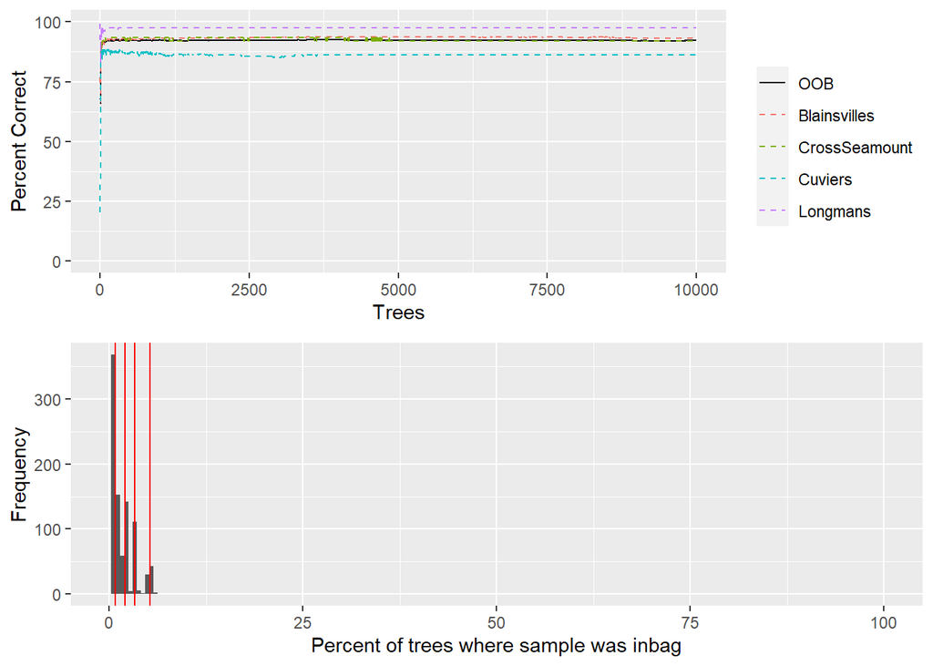

Run BANTER Event Model (stage 2)

```r
banter_model <- runBanterModel(banter_model, ntree=10e3, sampsize=4)
summary(banter_model)
```

Check for stability (are more trees needed?). If acceptable, save model with tree/sampsize info in the filename.

```r
saveRDS(banter_model, 'hawaii_banter_model_t5e3s10_t10e3s4.rds')
```

### *ICI Model*

Load data, initialize a BANTER model, and create an initial BANTER detector model (stage 1).

```r
banter_model_ici <- initBanterModel(banter_data_ici$events)
banter_model_ici <- addBanterDetector(banter_model_ici, banter_data_ici$detectors, ntree=5e3, sampsize=5, importance = TRUE)
```

Check for stability to see if we need more trees

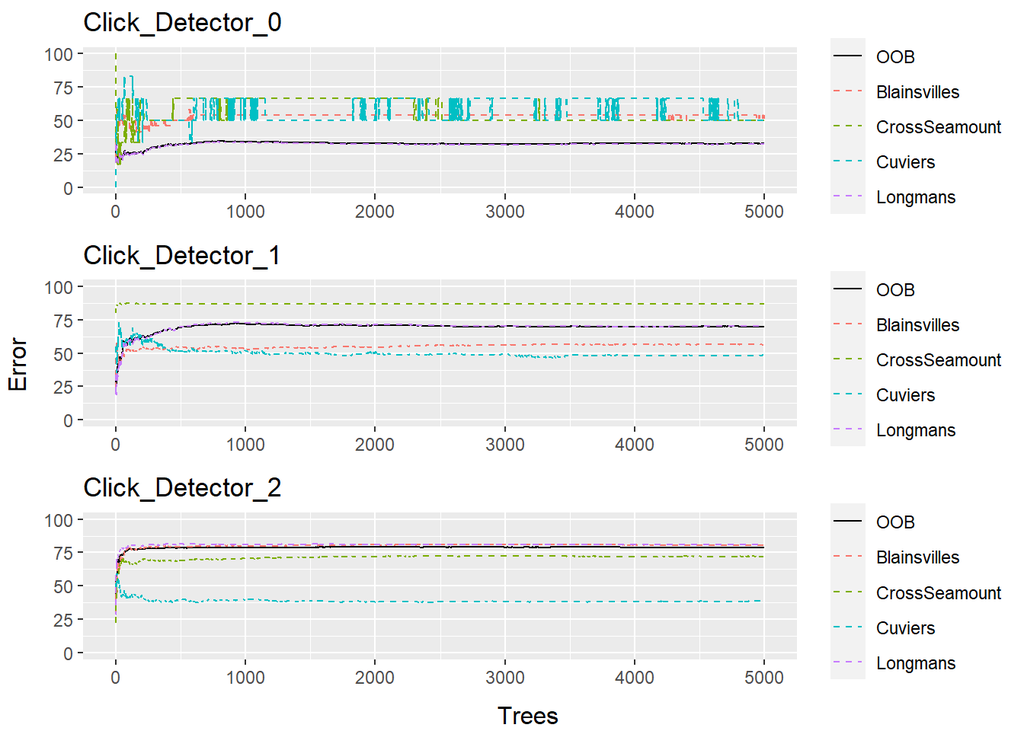

```r
plotDetectorTrace(banter_model_ici, detector = paste0('Click_Detector_', 0:2))
```

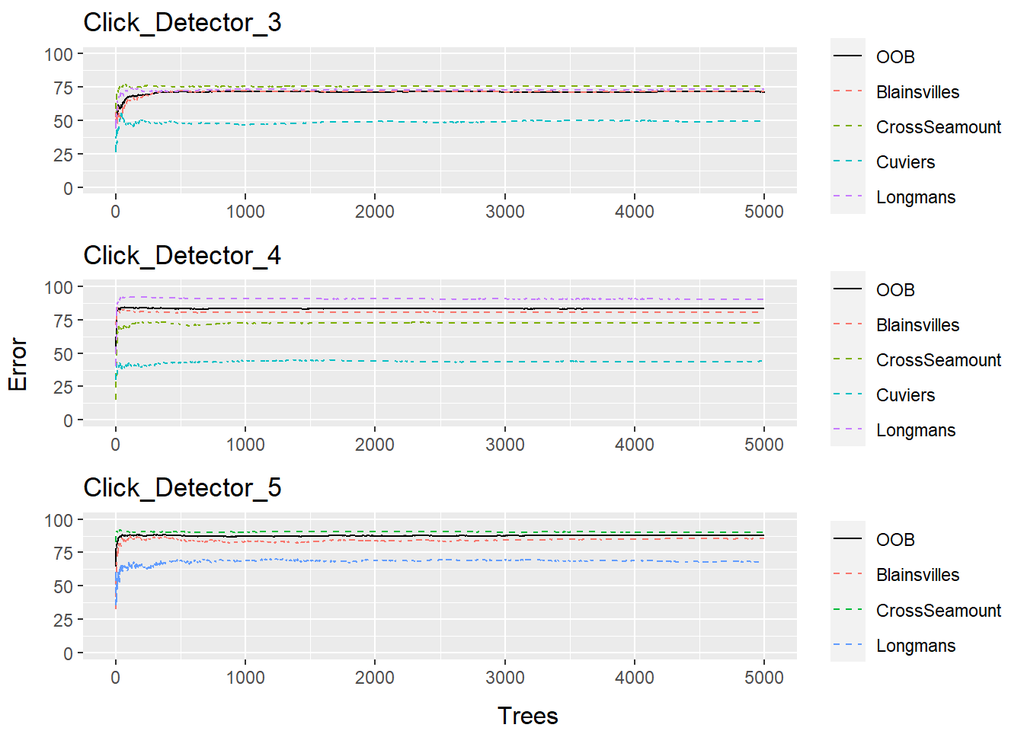

```r
plotDetectorTrace(banter_model_ici, detector = paste0('Click_Detector_', 3:5))
```

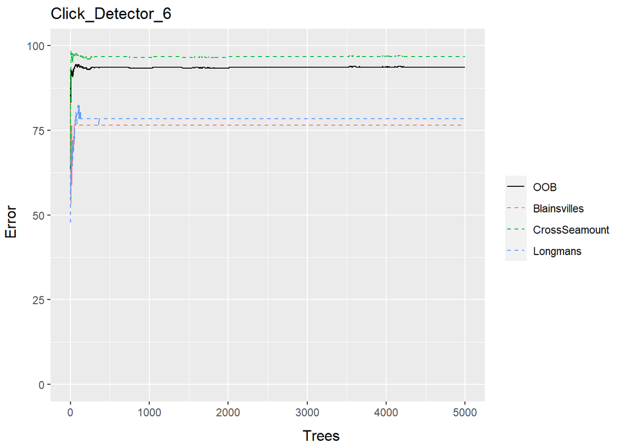

```r
plotDetectorTrace(banter_model_ici, detector = paste0('Click_Detector_', 6))
```

```r
summary(banter_model_ici)
```

```
## Model run times:
##                  start                 stop                  run.time
## Click_Detector_0 "2023-02-10 07:33:55" "2023-02-10 07:33:57" "2.74 secs"
## Click_Detector_1 "2023-02-10 07:32:34" "2023-02-10 07:33:54" "1.34 mins"
## Click_Detector_2 "2023-02-10 07:22:31" "2023-02-10 07:26:29" "3.95 mins"
## Click_Detector_3 "2023-02-10 07:26:29" "2023-02-10 07:31:19" "4.83 mins"
## Click_Detector_4 "2023-02-10 07:31:19" "2023-02-10 07:32:34" "1.25 mins"
## Click_Detector_5 "2023-02-10 07:33:57" "2023-02-10 07:34:01" "4 secs"
## Click_Detector_6 "2023-02-10 07:33:54" "2023-02-10 07:33:55" "0.41 secs"
## event            "2023-02-10 07:36:25" "2023-02-10 07:36:41" "15.51 secs"
##
## Number of events and model classification rate:
##         species num.events Click_Detector_0 Click_Detector_1 Click_Detector_2
## 1  Blainsvilles        521            54.17            56.34            80.43
## 2 CrossSeamount         76            50.00            86.68            72.13
## 3       Cuviers        201            50.00            48.59            38.57
## 4      Longmans        122            32.44            70.29            81.03
## 5       Overall        920            32.91            70.03            78.86
##   Click_Detector_3 Click_Detector_4 Click_Detector_5 Click_Detector_6 event
## 1            71.48            80.81            85.55            76.47 93.09
## 2            75.58            72.53            90.35            96.77 92.11
## 3            49.50            43.78               NA               NA 84.08
## 4            73.19            90.51            67.88            78.43 97.54
## 5            71.44            83.24            87.87            93.64 91.63
```

```
##
## << Summary for "event" model >>
```

```
##
## Number of trees: 10000
##
## Sample sizes:
##  Blainsvilles CrossSeamount       Cuviers      Longmans
##             4             4             4             4
##
## Distribution of percent correctly classified overall in last 5000 (50%) trees:
##    Min. 1st Qu.  Median    Mean 3rd Qu.    Max.
##   91.30   91.41   91.52   91.54   91.63   91.74
##
## Sample inbag proportion distribution:
##          Min. 1st Qu. Median Mean 3rd Qu. Max.
## expected  0.8     1.7    2.6  2.8     3.8  5.3
## observed  0.5     0.7    0.9  1.7     2.1  5.8
##
## Confusion matrix:
##               Blainsvilles CrossSeamount Cuviers Longmans pct.correct LCI_0.95
## Blainsvilles           485            10      25        1    93.09021 90.56200
## CrossSeamount            4            70       2        0    92.10526 83.60441
## Cuviers                 17             1     169       14    84.07960 78.27488
## Longmans                 0             0       3      119    97.54098 92.98183
## Overall                 NA            NA      NA       NA    91.63043 89.65036
##               UCI_0.95
## Blainsvilles  95.11388
## CrossSeamount 97.04762
## Cuviers       88.84841
## Longmans      99.48999
## Overall       93.33864
```

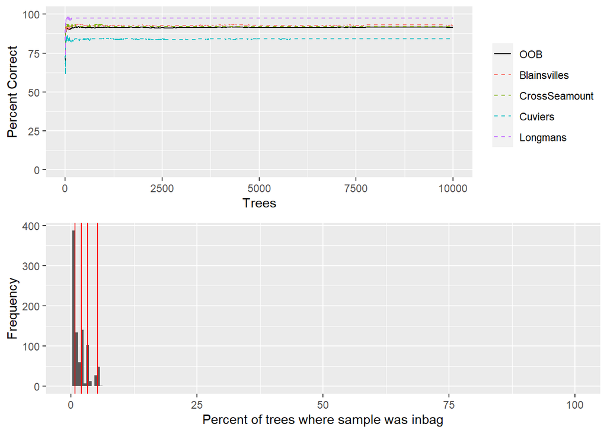

Run BANTER Event Model (stage 2)

```r
banter_model_ici <- runBanterModel(banter_model_ici, ntree=10e3, sampsize=4)
summary(banter_model_ici)
```

Check for stability (are more trees needed?). If acceptable, save model with tree/sampsize info in the filename.

```r
saveRDS(banter_model_ici, 'hawaii_banter_model_ici_t5e3s5_t10e3s4.rds')
```

## BANTER Analytics

There are a number of visualizations/data products that allow us to visualize our BANTER classifier; most use the rfPermute package (see [BANTER Guidelines](https://taikisan21.github.io/PAMpal/banterGuide.html) for more information)

First, identify the model you would like to examine (comment out the model you do not want to examine).

```r
model <- banter_model
modelname <- "banter_model"

model_ici <- banter_model_ici
modelname_ici <- "banter_model_ici"
```

Extract the Random Forest model object from our BANTER model for analysis.

```r
banter_model_RF <- getBanterModel(model)
banter_model_ici_RF <- getBanterModel(model_ici)
```

Confusion Matrix

```r
hawaii_confuseMatrix <- rfPermute::confusionMatrix(banter_model_RF)
hawaii_confuseMatrix <- kable(hawaii_confuseMatrix, align = "c", digits = c(0,0,0,0,2,2,2))%>%
  kable_classic()%>%
  column_spec(5, border_right = TRUE)%>%
  row_spec(0, bold = TRUE)%>%
  row_spec(5,hline_after = TRUE)%>%
  row_spec(5, bold = TRUE)%>%
  save_kable(paste(modelname, "hawaii_confuseMatrix.png", sep="_"), zoom = 2)
```

```
## save_kable will have the best result with magick installed.
```

```r
hawaii_ici_confuseMatrix <- rfPermute::confusionMatrix(banter_model_ici_RF)
hawaii_ici_confuseMatrix <- kable(hawaii_ici_confuseMatrix, align = "c", digits = c(0,0,0,0,2,2,2))%>%
  kable_classic()%>%
  column_spec(5, border_right = TRUE)%>%
  row_spec(0, bold = TRUE)%>%
  row_spec(5,hline_after = TRUE)%>%
  row_spec(5, bold = TRUE)%>%
  save_kable(paste(modelname_ici, "hawaii_ici_confuseMatrix.png", sep="_"), zoom = 2)
```

```
## save_kable will have the best result with magick installed.
```

Proximity Plot

```r
png(paste(modelname, "hawaii_proximity.png", sep="_"), width = 20, height = 20, units = 'cm', res = 300)
hawaii_proximityPlot <- plotProximity(banter_model_RF)
dev.off()
```

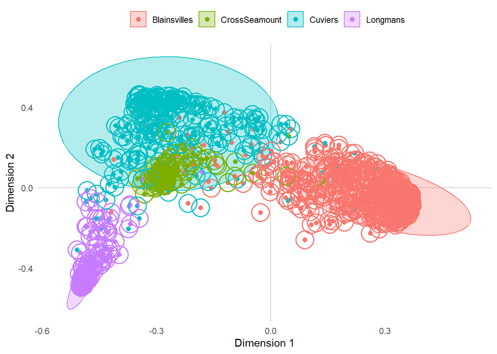

```r
hawaii_proximityPlot <- plotProximity(banter_model_RF)
```

```r
png(paste(modelname_ici, "hawaii_proximity.png", sep="_"), width = 20, height = 20, units = 'cm', res = 300)
ici_hawaii_proximityPlot <- plotProximity(banter_model_ici_RF)
dev.off()
```

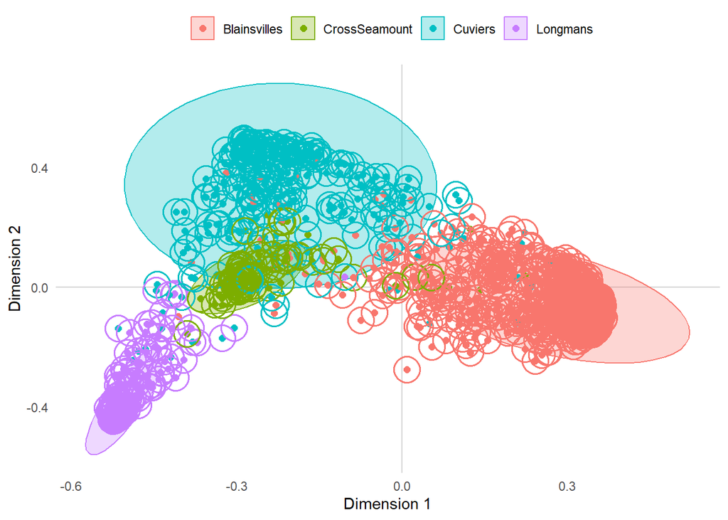

```r
ici_hawaii_proximityPlot <- plotProximity(banter_model_ici_RF)
```

Importance Heatmap

```r
png(paste(modelname, "hawaii_importance.png", sep="_"), width = 30, height = 25, units = 'cm', res = 300)
plotImportance(banter_model_RF, plot.type="heatmap")
dev.off()
```

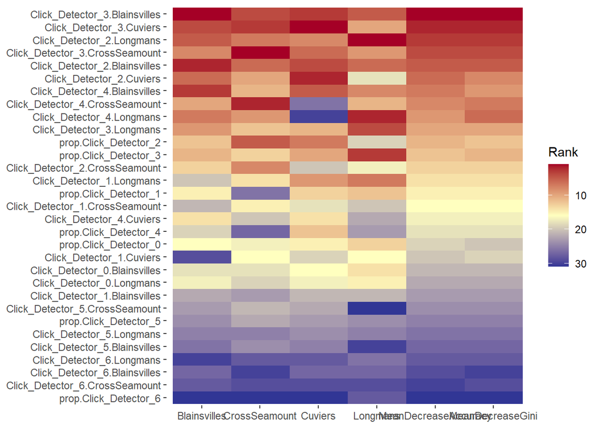

```r
hawaii_importance <- plotImportance(banter_model_RF, plot.type="heatmap")
```

```r
png(paste(modelname_ici, "hawaii_importance.png", sep="_"), width = 30, height = 25, units = 'cm', res = 300)
plotImportance(banter_model_ici_RF, plot.type="heatmap")
dev.off()
```

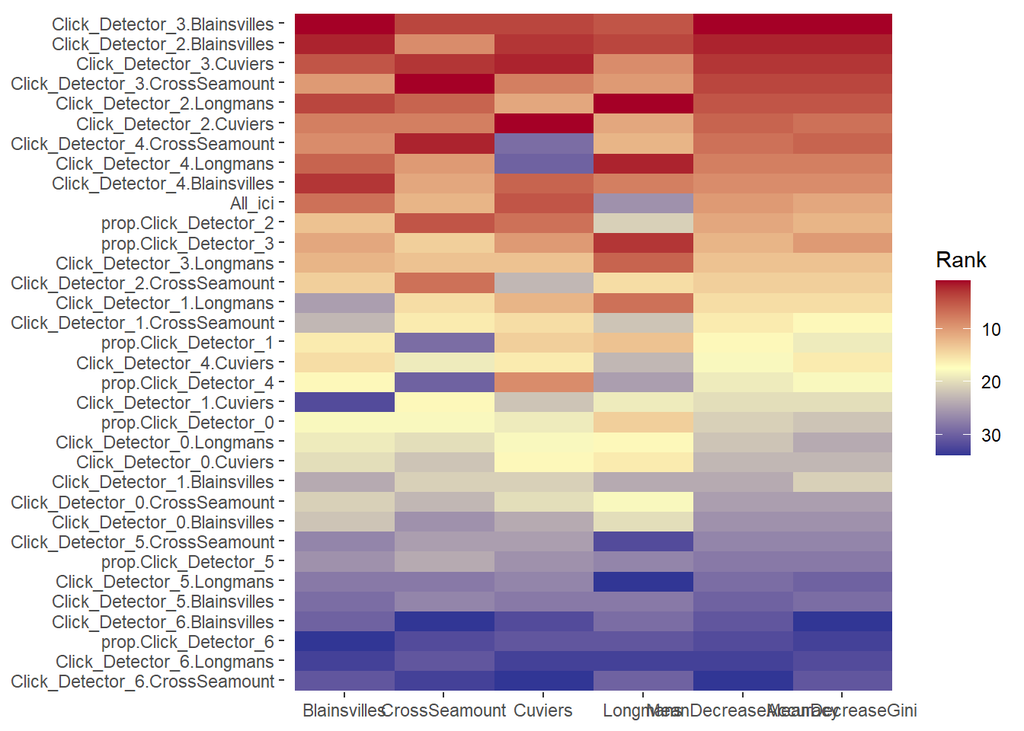

```r
ici_hawaii_importance <- plotImportance(banter_model_ici_RF, plot.type="heatmap")
```

PlotVotes

```r
png(paste(modelname, "hawaii_votes.png", sep="_"), width = 20, height = 20, units = 'cm',  res = 300)
plotVotes(banter_model_RF)
dev.off()
```

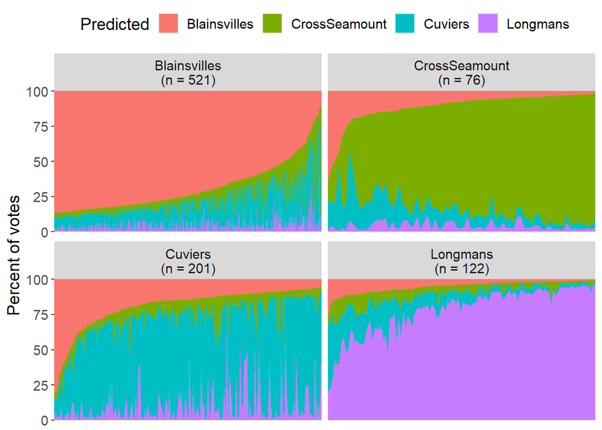

```r
hawaii_votes <- plotVotes(banter_model_RF)
```

```r
png(paste(modelname_ici, "hawaii_votes.png", sep="_"), width = 20, height = 20, units = 'cm',  res = 300)
plotVotes(banter_model_ici_RF)
dev.off()
```

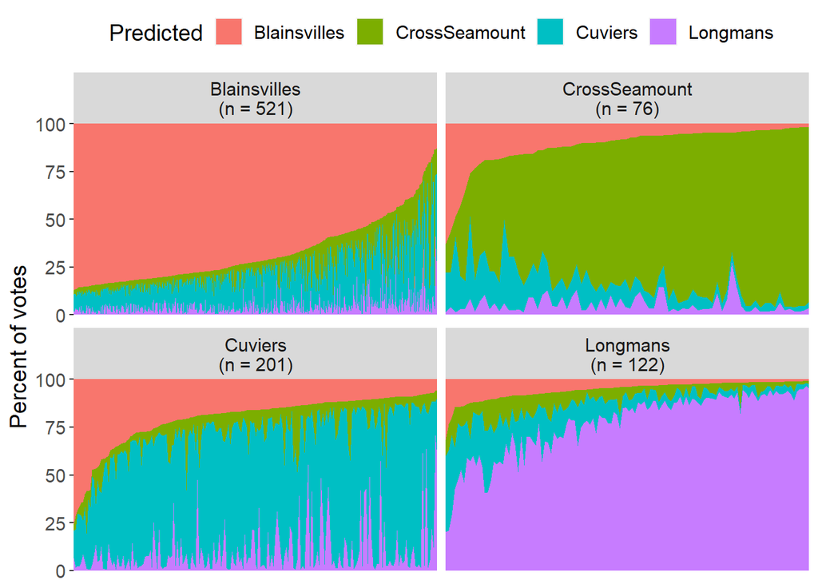

```r
ici_hawaii_votes <- plotVotes(banter_model_ici_RF)
```

Class Priors (Expected Error Rate)

```r
hawaii_priors <- classPriors(banter_model_RF, NULL)
```

Plot Confusion Matrix Heat Map

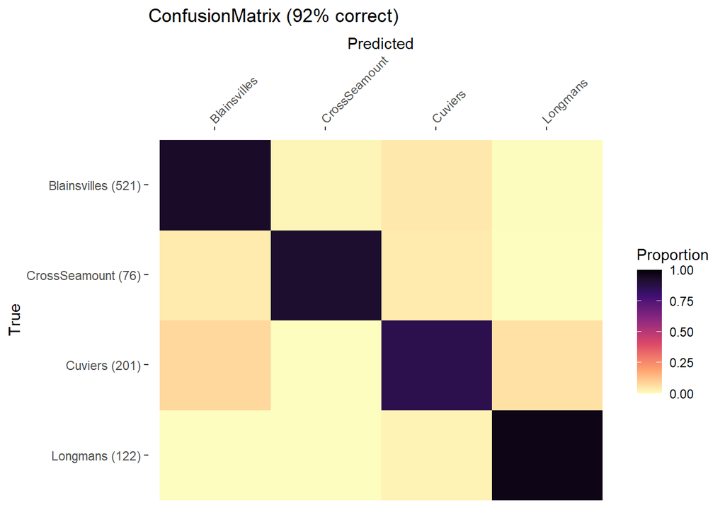

```r
plotConfMat(banter_model_RF, title="ConfusionMatrix", plot=TRUE)
```

Plot Error Trace for Banter Model

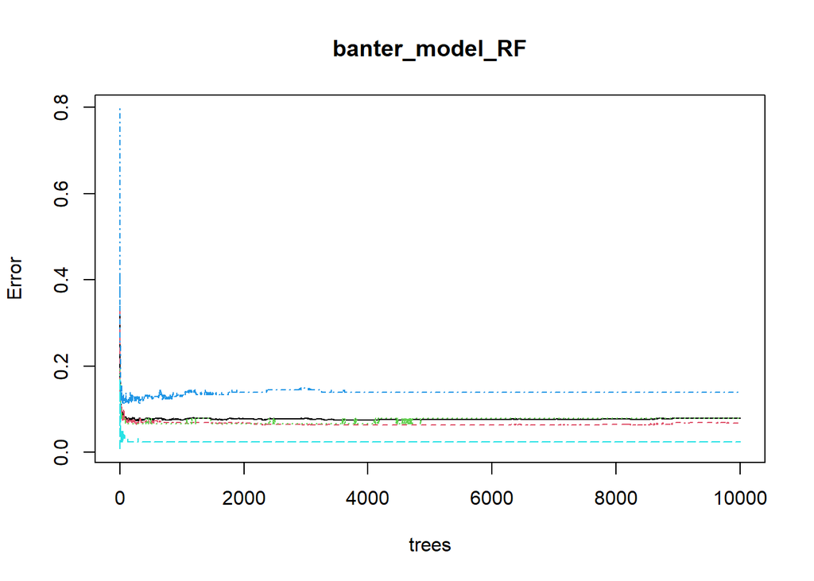

```r
plot(banter_model_RF)
```

Plot Predicted Probabilities

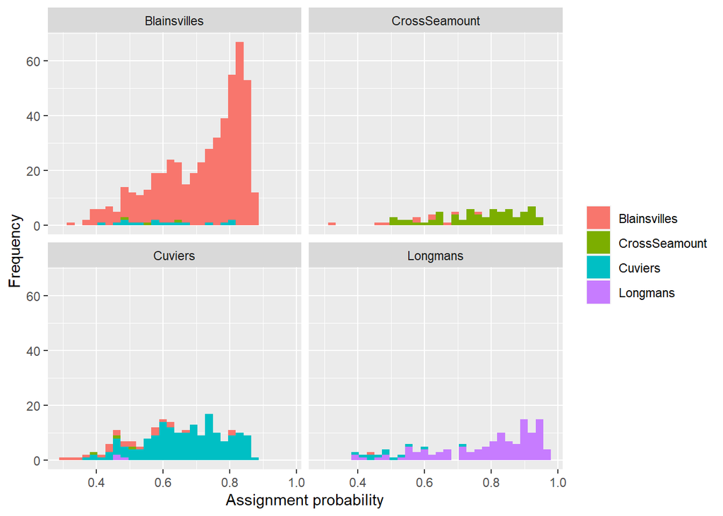

```r
plotPredictedProbs(banter_model_RF, bins=30, plot=TRUE)
```